# The Freemium business model

High Note is an anonymized real music streaming company similar to Last.fm, Spotify or Pandora which uses a freemium business model. The expectation is to use the High Note customer data, and build a "free to fee" strategy to convert free accounts to premium subscribers.

We start of by importing the below packages for the functionalities as commented below.

```r
library(dplyr)             # Package for Data preprocessing
library(psych)             # Package for summarising data in tables
library(ggplot2)           # Package for Visualisations
library(MatchIt)           # Package for Matching based on propensity score
library(corrplot)          # Package for Correlation plots
library(gridExtra)         # Package for plotting multiple plots
library(ggExtra)           # Package for Visual Enhancement
library(car)               # Package for VIF
options(scipen = 999)      # To ensure results are not in exponential
```

We change the working directory, import the csv file and check the dimensions of the dataframe

```r
getwd()
setwd('C:/Users/Nijanth Anand/Downloads/BANA277-Customer Analytics/Assignment - MidTerm')
data=read.csv("HighNote Data Midterm.csv",na.strings=c(""," ","NA"))
print('Dimension of data is')
print(paste('Row Count:',dim(data)[1]))
print(paste('Column Count:',dim(data)[2]))
```

'C:/Users/Nijanth Anand/Anaconda Workspace'

```
[1] "Dimension of data is"
[1] "Row Count: 43827"
[1] "Column Count: 16"
```

We check if there are NA Values

```r
sum(is.na(data))
```

0

Since there are no NA values, we work on the descriptive statistics based on the adopter value as stated in the reading

```r
xyz<- data[data$adopter==1,c(2,3,4,8,9,12,11,13,10,7)]
a<-psych::describe(xyz,skew=FALSE)
xyz<- data[data$adopter==0,c(2,3,4,8,9,12,11,13,10,7)]
b<-psych::describe(xyz,skew=FALSE)
print("For Adopter =1")
a
print("For Adopter =0")
b
#data[data$adopter==0,-1] %>% psych::describe(,skew=FALSE,mat=TRUE)
```

```
[1] "For Adopter =1"
```

|  | vars | n | mean | sd | min | max | range | se |
| --- | --- | --- | --- | --- | --- | --- | --- | --- |
| age | 1 | 3527 | 25.9798696 | 6.8435969 | 8 | 73 | 65 | 0.115234280 |
| male | 2 | 3527 | 0.7292316 | 0.4444197 | 0 | 1 | 1 | 0.007483255 |
| friend_cnt | 3 | 3527 | 39.7337681 | 117.2748963 | 1 | 5089 | 5088 | 1.974705464 |
| subscriber_friend_cnt | 4 | 3527 | 1.6368018 | 5.8499808 | 0 | 287 | 287 | 0.098503511 |
| songsListened | 5 | 3527 | 33758.0405444 | 43592.7275397 | 0 | 817290 | 817290 | 734.025780107 |
| playlists | 6 | 3527 | 0.9007655 | 2.5633919 | 0 | 118 | 118 | 0.043163065 |
| posts | 7 | 3527 | 21.2004536 | 221.9934445 | 0 | 8506 | 8506 | 3.737983845 |
| shouts | 8 | 3527 | 99.4397505 | 1156.0731310 | 0 | 65872 | 65872 | 19.466262602 |
| lovedTracks | 9 | 3527 | 264.3407995 | 491.4267571 | 0 | 10220 | 10220 | 8.274772631 |
| friend_country_cnt | 10 | 3527 | 7.1888290 | 8.8598183 | 0 | 136 | 136 | 0.149183945 |

```
[1] "For Adopter =0"
```

|  | vars | n | mean | sd | min | max | range | se |
| --- | --- | --- | --- | --- | --- | --- | --- | --- |
| age | 1 | 40300 | 23.9484367 | 6.3718313 | 8 | 79 | 71 | 0.031740353 |
| male | 2 | 40300 | 0.6218610 | 0.4849286 | 0 | 1 | 1 | 0.002415601 |
| friend_cnt | 3 | 40300 | 18.4916625 | 57.4811697 | 1 | 4957 | 4956 | 0.286334101 |
| subscriber_friend_cnt | 4 | 40300 | 0.4174690 | 2.4181507 | 0 | 309 | 309 | 0.012045667 |
| songsListened | 5 | 40300 | 17589.4415136 | 28416.0229266 | 0 | 1000000 | 1000000 | 141.550292596 |
| playlists | 6 | 40300 | 0.5492804 | 1.0719556 | 0 | 98 | 98 | 0.005339791 |
| posts | 7 | 40300 | 5.2930025 | 104.3094298 | 0 | 12309 | 12309 | 0.519602280 |
| shouts | 8 | 40300 | 29.9726551 | 150.6897894 | 0 | 7736 | 7736 | 0.750639308 |
| lovedTracks | 9 | 40300 | 86.8226303 | 263.5804416 | 0 | 12522 | 12522 | 1.312987702 |
| friend_country_cnt | 10 | 40300 | 3.9578908 | 5.7641675 | 0 | 129 | 129 | 0.028713364 |

We can see there is a difference in means between adopter=0 and adopter=1 grouped records, for instance the average songs listened by adopters is 33K while non adopters have listened to about 17K songs which is half of it.

We assign ID attribute to NULL since we will not be using it further for the modelling and descriptive analytics

```r
data$ID<- NULL
```

# Descriptive Statistics

Assign a new data frame for descriptive statistics computation since we will be factorising variables

```r
data_desc<- data
```

We make the adopter variable a String Factor to help visualize how adopters and non-adopters differ from each other.

```r
data_desc$paid <- ifelse(data_desc$adopter==1,'Subscriber','Free User')
table(data_desc$paid)
```

```
 Free User Subscriber
     40300       3527
```

## Correlation Analysis

```r
str(data)
```

```
'data.frame':	43827 obs. of  15 variables:
 $ age                  : int  22 35 27 21 24 21 20 23 24 34 ...
 $ male                 : int  0 0 1 0 0 1 0 1 0 1 ...
 $ friend_cnt           : int  8 2 2 28 65 12 15 57 4 13 ...
 $ avg_friend_age       : num  22.6 28 23 22.9 22.3 ...
 $ avg_friend_male      : num  0.429 1 1 0.5 0.914 ...
 $ friend_country_cnt   : int  1 2 1 7 9 1 1 14 1 3 ...
 $ subscriber_friend_cnt: int  0 0 0 1 0 0 0 1 0 0 ...
 $ songsListened        : int  9687 0 508 1357 89984 124547 24852 99877 6125 15997 ...
 $ lovedTracks          : int  194 0 0 32 20 10 391 125 42 82 ...
 $ posts                : int  0 0 0 0 2 0 6 89 0 0 ...
 $ playlists            : int  1 0 1 0 0 1 1 1 0 1 ...
 $ shouts               : int  8 0 2 1 81 2 67 44 5 3 ...
 $ adopter              : int  0 0 0 0 0 0 0 0 0 0 ...
 $ tenure               : int  59 35 42 25 67 53 56 71 34 49 ...
 $ good_country         : int  1 0 0 0 0 1 1 0 1 1 ...
```

### Correlation Analysis of Demographics

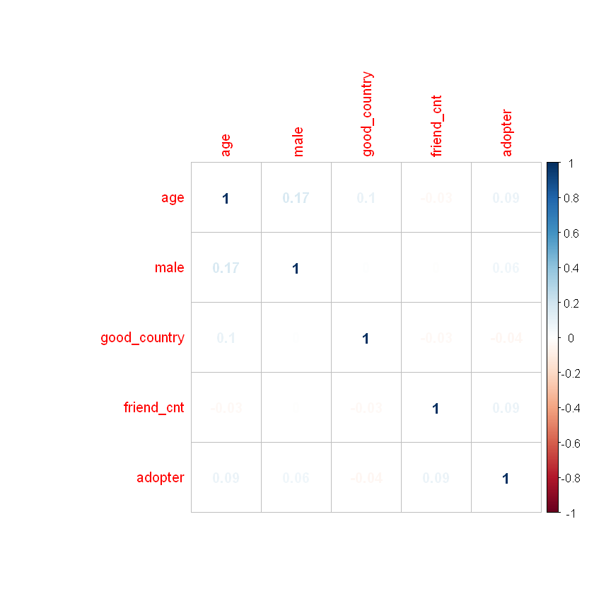

```r
cor_data<-data[,c('age','male','good_country','friend_cnt','adopter')]
M=cor(cor_data,method = c("pearson", "kendall", "spearman"))
corrplot(M,method="number",addrect=2)  ##circle
```

### Correlation Analysis of Peer Influence

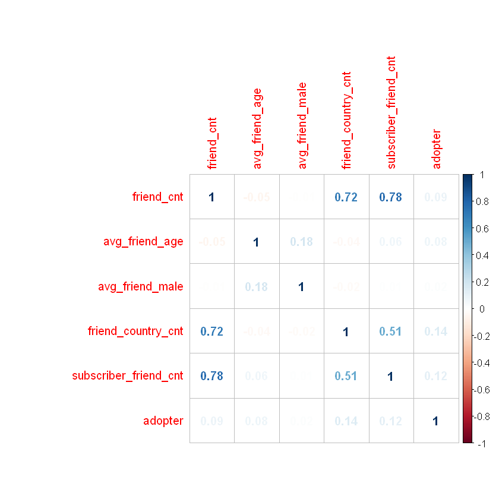

```r
cor_data<-data[,c('friend_cnt','avg_friend_age','avg_friend_male','friend_country_cnt','subscriber_friend_cnt','adopter')]
M=cor(cor_data,method = c("pearson", "kendall", "spearman"))
corrplot(M,method="number",addrect=2)  ##circle
```

### Correlation Analysis of User Engagement

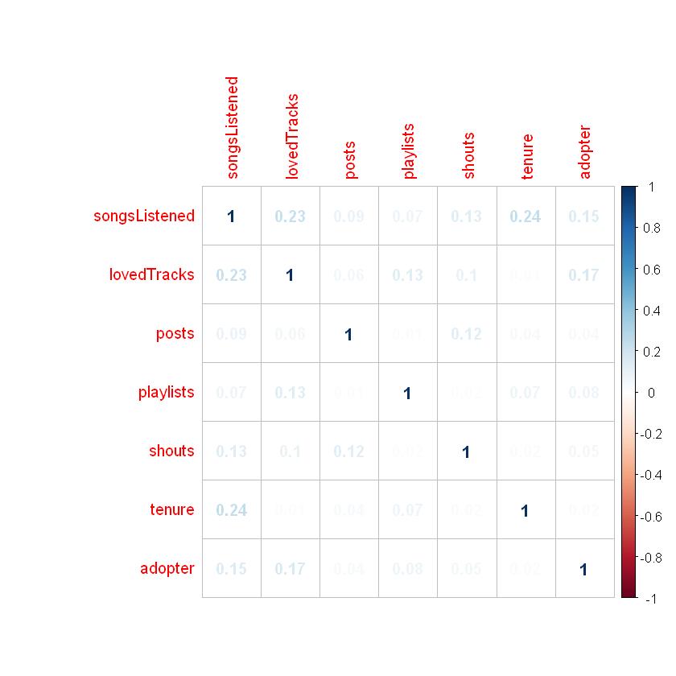

```r
cor_data<-data[,c('songsListened','lovedTracks','posts','playlists','shouts','tenure','adopter')]
M=cor(cor_data,method = c("pearson", "kendall", "spearman"))
corrplot(M,method="number",addrect=2)  ##circle
```

### Descriptive Graphs for Demographics

Plot between friends count and age which is studied for users based on country and adopter status.

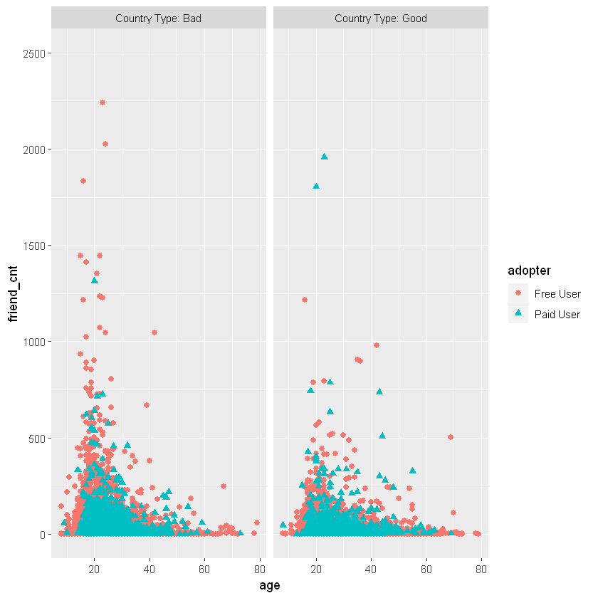

```r
labs <- paste("Country Type:", c("Good", "Bad"))
labs2 <- paste(c("Paid User", "Free User"))
data %>% mutate(good_country = ifelse(good_country == 1, labs[1], labs[2]))%>%
  mutate(adopter = ifelse(adopter == 1, labs2[1], labs2[2]))%>%
  ggplot(aes(x=age, y=friend_cnt,shape=adopter, color=adopter)) + geom_point(size=2)+
  facet_wrap(~good_country)+ylim(0,2500)
```

We can conclude that the number of friends is relatively higher in bad countries and paid users are normally distributed along age specifically between th20 and 40.

Box Plots for Demographics to study the distribution

```
[1] "Box Plot for Demographic understanding to help visualize how adopters and non-adopters perform"
```

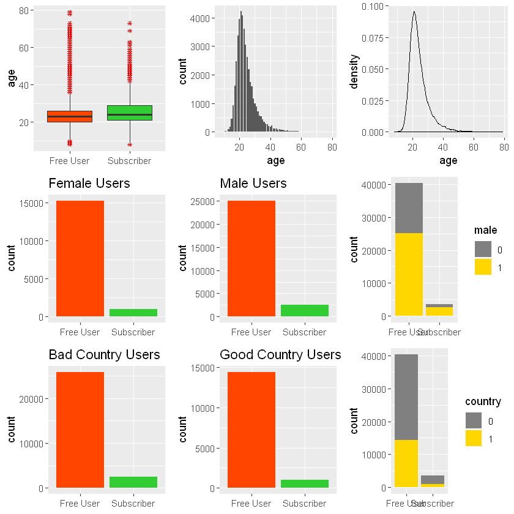

```r
data_desc$paid=as.factor(data_desc$paid)
data_desc$male=as.factor(data_desc$male)
data_desc$good_country=as.factor(data_desc$good_country)
print("Box Plot for Demographic understanding to help visualize how adopters and non-adopters perform")
require(gridExtra)
abc1 <- ggplot(data_desc, aes(x=paid, y=age)) + geom_boxplot(aes(fill=paid),outlier.colour="red", outlier.shape=8,outlier.size=1)
abc1 <- abc1 + scale_fill_manual(values=c("#FF4500", "#32CD32")) +theme(legend.position="none")+theme(axis.title.x=element_blank())
abc2<- ggplot(data_desc, aes(x=age)) + geom_bar()
abc3<- ggplot(data_desc, aes(x=age)) + geom_density(kernel='gaussian')

data1<-data_desc[data_desc$male==0,]
abc4 <- ggplot(data1, aes(x=paid)) +labs(title = "Female Users")+ geom_bar(aes(fill=paid) )+theme(axis.title.x=element_blank())+ scale_fill_manual(values=c("#FF4500", "#32CD32"))+theme(legend.position="none")
data2<-data_desc[data_desc$male==1,]
abc5 <- ggplot(data2, aes(x=paid)) +labs(title = "Male Users")+ geom_bar(aes(fill=paid) )+theme(axis.title.x=element_blank())+ scale_fill_manual(values=c("#FF4500", "#32CD32"))+theme(legend.position="none") #geom_bar(stat="identity") #geom_histogram()
abc6 <- ggplot(data_desc, aes(paid))
abc6 <- abc6  + geom_bar(aes(fill = male))+ scale_fill_manual(values=c("#808080", "#FFD700"))+theme(axis.title.x=element_blank())


data1<-data_desc[data_desc$good_country==0,]
abc7 <- ggplot(data1, aes(x=paid)) +labs(title = "Bad Country Users")+ geom_bar(aes(fill=paid) )+theme(axis.title.x=element_blank())+ scale_fill_manual(values=c("#FF4500", "#32CD32"))+theme(legend.position="none")
data2<-data_desc[data_desc$good_country==1,]
abc8 <- ggplot(data2, aes(x=paid)) +labs(title = "Good Country Users")+ geom_bar(aes(fill=paid) ) +theme(axis.title.x=element_blank())+ scale_fill_manual(values=c("#FF4500", "#32CD32"))+theme(legend.position="none")#geom_bar(stat="identity") #geom_histogram()
data_descx=mutate(data_desc,country=good_country)
abc9 <- ggplot(data_descx, aes(paid))
abc9 <- abc9  + geom_bar(aes(fill = country))+ scale_fill_manual(values=c("#808080", "#FFD700"))+theme(axis.title.x=element_blank())

grid.arrange(abc1,abc2,abc3,abc4,abc5,abc6,abc7,abc8,abc9, ncol=3)
```

### Descriptive Graphs for Peer Influence

Plot between friend count and subscriber count to understand if having more friends leads to more subscriber friends based on gender and adopter.

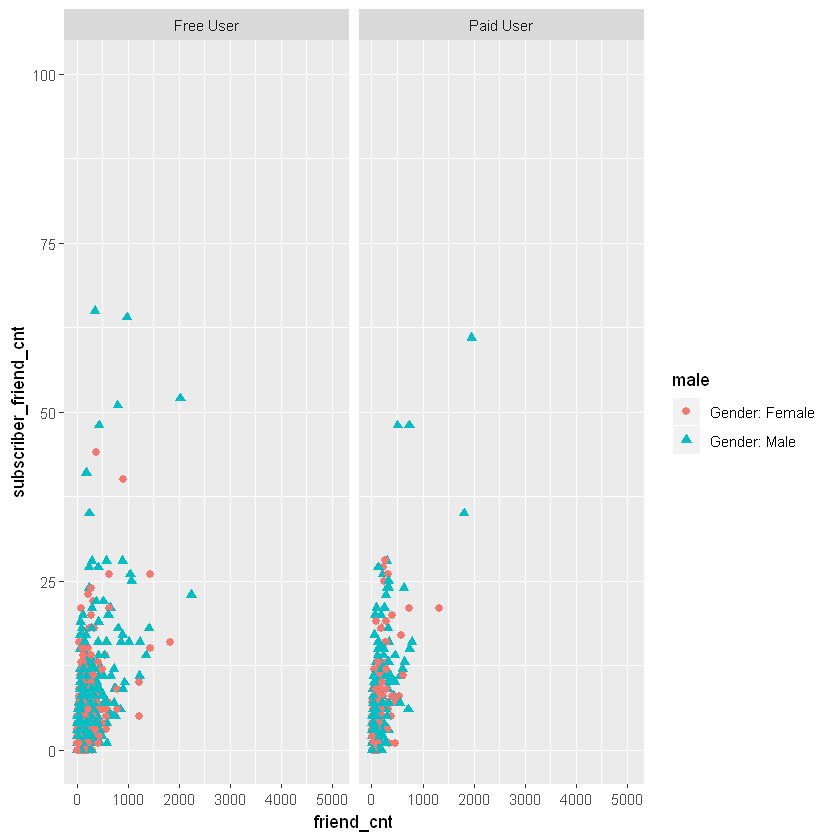

```r
labs <- paste("Gender:", c("Male", "Female"))
labs2 <- paste(c("Paid User", "Free User"))
data %>% mutate(male = ifelse(male == 1, labs[1], labs[2]))%>%
  mutate(adopter = ifelse(adopter == 1, labs2[1], labs2[2]))%>%
  ggplot(aes(x=friend_cnt, y=subscriber_friend_cnt,shape=male, color=male)) + geom_point(size=2)+
  facet_wrap(~adopter)+ylim(0,100)
```

We plot the Box plots to understand the spread of the variables across adopters and non-adopters

```
[1] "Box Plot for Peer Influence understanding to help visualize how adopters and non-adopters perform"
```

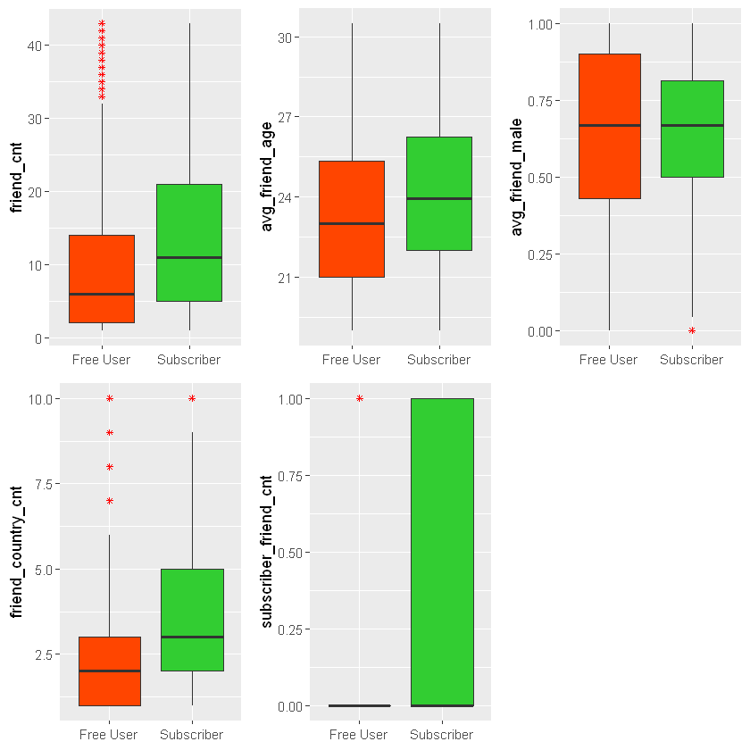

```r
print("Box Plot for Peer Influence understanding to help visualize how adopters and non-adopters perform")
abc2 <- ggplot(data_desc, aes(x=paid, y=friend_cnt)) + geom_boxplot(aes(fill=paid),outlier.colour="red", outlier.shape=8,outlier.size=1)
abc2 <- abc2 + scale_fill_manual(values=c("#FF4500", "#32CD32"))+theme(legend.position="none")+scale_y_continuous(limits = quantile(data_desc$friend_cnt, c(0.1, 0.9)))+theme(axis.title.x=element_blank())
abc3 <- ggplot(data_desc, aes(x=paid, y=avg_friend_age)) + geom_boxplot(aes(fill=paid),outlier.colour="red", outlier.shape=8,outlier.size=1)
abc3 <- abc3 + scale_fill_manual(values=c("#FF4500", "#32CD32"))+theme(legend.position="none")+scale_y_continuous(limits = quantile(data_desc$avg_friend_age, c(0.1, 0.9)))+theme(axis.title.x=element_blank())
abc4 <- ggplot(data_desc, aes(x=paid, y=avg_friend_male)) + geom_boxplot(aes(fill=paid),outlier.colour="red", outlier.shape=8,outlier.size=1)
abc4 <- abc4 + scale_fill_manual(values=c("#FF4500", "#32CD32"))+theme(legend.position="none")+scale_y_continuous(limits = quantile(data_desc$avg_friend_male, c(0.1, 0.9)))+theme(axis.title.x=element_blank())
abc5 <- ggplot(data_desc, aes(x=paid, y=friend_country_cnt)) + geom_boxplot(aes(fill=paid),outlier.colour="red", outlier.shape=8,outlier.size=1)
abc5 <- abc5 + scale_fill_manual(values=c("#FF4500", "#32CD32"))+theme(legend.position="none")+scale_y_continuous(limits = quantile(data_desc$friend_country_cnt, c(0.1, 0.9)))+theme(axis.title.x=element_blank())
abc6 <- ggplot(data_desc, aes(x=paid, y=subscriber_friend_cnt)) + geom_boxplot(aes(fill=paid),outlier.colour="red", outlier.shape=8,outlier.size=1)
abc6 <- abc6 + scale_fill_manual(values=c("#FF4500", "#32CD32"))+theme(legend.position="none")+scale_y_continuous(limits = quantile(data_desc$subscriber_friend_cnt, c(0.1, 0.9)))+theme(axis.title.x=element_blank())
grid.arrange(abc2,abc3,abc4,abc5,abc6, ncol=3)
```

### Descriptive Graphs for User Engagement

Plot between songs listened and loved to understand based on gender and adopter to check if user engagement changes based on the said covariants

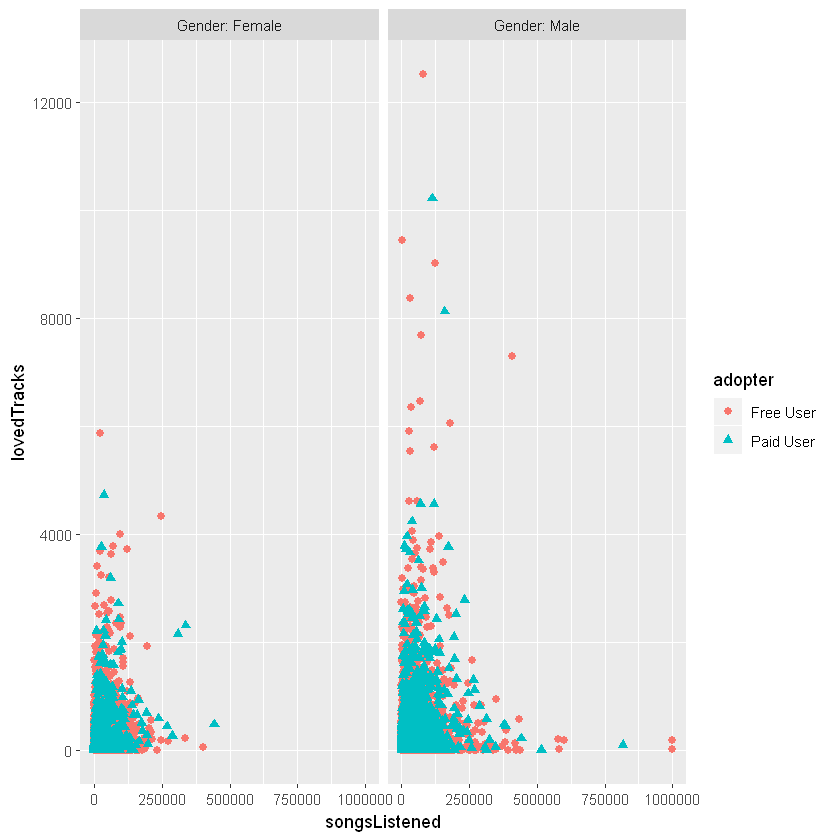

```r
labs <- paste("Gender:", c("Male", "Female"))
labs2 <- paste(c("Paid User", "Free User"))
data %>% mutate(male = ifelse(male == 1, labs[1], labs[2]))%>%
  mutate(adopter = ifelse(adopter == 1, labs2[1], labs2[2]))%>%
  ggplot(aes(x=songsListened, y=lovedTracks,shape=adopter, color=adopter)) + geom_point(size=2)+
  facet_wrap(~male)#+ylim(0,100)
```

We can observe that in the given sample, male users listen to more number of songs compared to female users and the users who have listened to the maximum number of songs or at the top 95th percentile aren't essentially paid customers.

Plot between songs listened and playlists to understand based on gender and adopter to check if user engagement changes based on the said covariants

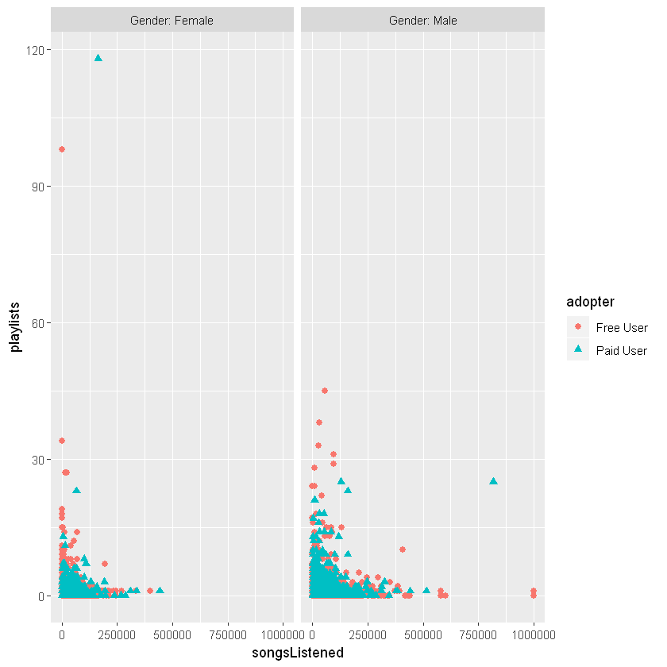

```r
labs <- paste("Gender:", c("Male", "Female"))
labs2 <- paste(c("Paid User", "Free User"))
data %>% mutate(male = ifelse(male == 1, labs[1], labs[2]))%>%
  mutate(adopter = ifelse(adopter == 1, labs2[1], labs2[2]))%>%
  ggplot(aes(x=songsListened, y=playlists,shape=adopter, color=adopter)) + geom_point(size=2)+
  facet_wrap(~male) #+ylim(0,150)
```

We plot the Box plots to understand the spread of the variables across adopters and non-adopters

```
[1] "Box Plot for User Engagement Influence understanding to help visualize how adopters and non-adopters perform"
```

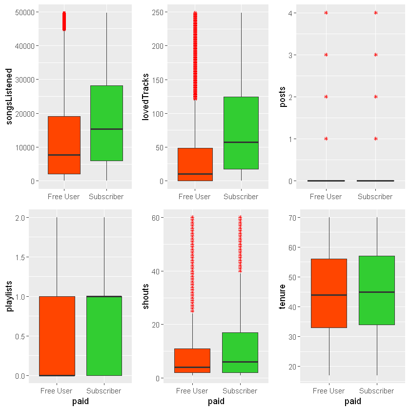

```r
print("Box Plot for User Engagement Influence understanding to help visualize how adopters and non-adopters perform")
abc7 <- ggplot(data_desc, aes(x=paid, y=songsListened)) + geom_boxplot(aes(fill=paid),outlier.colour="red", outlier.shape=8,outlier.size=1)
abc7 <- abc7 + scale_fill_manual(values=c("#FF4500", "#32CD32"))+theme(legend.position="none")+scale_y_continuous(limits = quantile(data_desc$songsListened, c(0.1, 0.9)))+theme(axis.title.x=element_blank())
abc8 <- ggplot(data_desc, aes(x=paid, y=lovedTracks)) + geom_boxplot(aes(fill=paid),outlier.colour="red", outlier.shape=8,outlier.size=1)
abc8 <- abc8 + scale_fill_manual(values=c("#FF4500", "#32CD32"))+theme(legend.position="none")+scale_y_continuous(limits = quantile(data_desc$lovedTracks, c(0.1, 0.9)))+theme(axis.title.x=element_blank())
abc9 <- ggplot(data_desc, aes(x=paid, y=posts)) + geom_boxplot(aes(fill=paid),outlier.colour="red", outlier.shape=8,outlier.size=1)
abc9 <- abc9 + scale_fill_manual(values=c("#FF4500", "#32CD32"))+theme(legend.position="none")+scale_y_continuous(limits = quantile(data_desc$posts, c(0.1, 0.9)))+theme(axis.title.x=element_blank())
abc10 <- ggplot(data_desc, aes(x=paid, y=playlists)) + geom_boxplot(aes(fill=paid),outlier.colour="red", outlier.shape=8,outlier.size=1)
abc10 <- abc10 + scale_fill_manual(values=c("#FF4500", "#32CD32"))+theme(legend.position="none")+scale_y_continuous(limits = quantile(data_desc$playlists, c(0, 0.95)))
abc11 <- ggplot(data_desc, aes(x=paid, y=shouts)) + geom_boxplot(aes(fill=paid),outlier.colour="red", outlier.shape=8,outlier.size=1)
abc11 <- abc11 + scale_fill_manual(values=c("#FF4500", "#32CD32"))+theme(legend.position="none")+scale_y_continuous(limits = quantile(data_desc$shouts, c(0.1, 0.9)))
abc12 <- ggplot(data_desc, aes(x=paid, y=tenure)) + geom_boxplot(aes(fill=paid),outlier.colour="red", outlier.shape=8,outlier.size=1)
abc12 <- abc12 + scale_fill_manual(values=c("#FF4500", "#32CD32"))+theme(legend.position="none")+scale_y_continuous(limits = quantile(data_desc$tenure, c(0.1, 0.9)))
grid.arrange(abc7,abc8,abc9,abc10,abc11,abc12, ncol=3)
```

We plot the variation of parameters based on the user engagement.

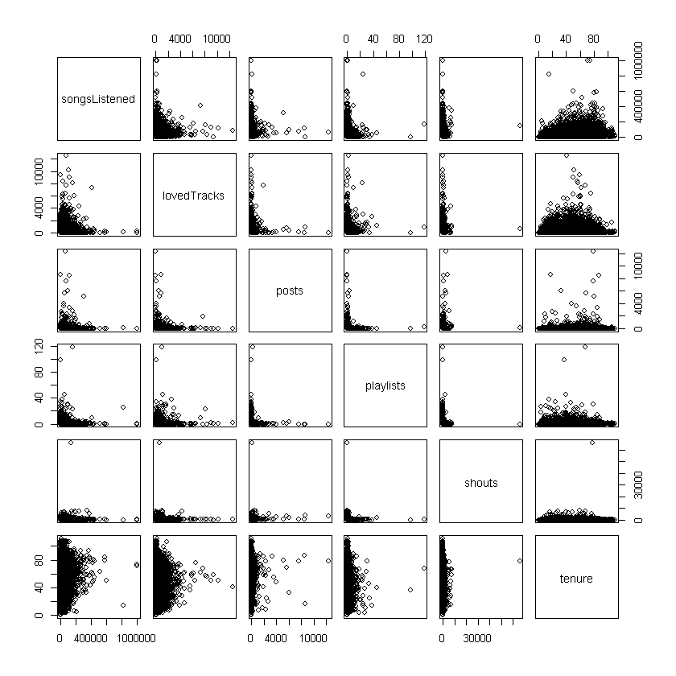

```r
pairs(data[,c(8:12,14)])
```

Correlation plot of all predictors

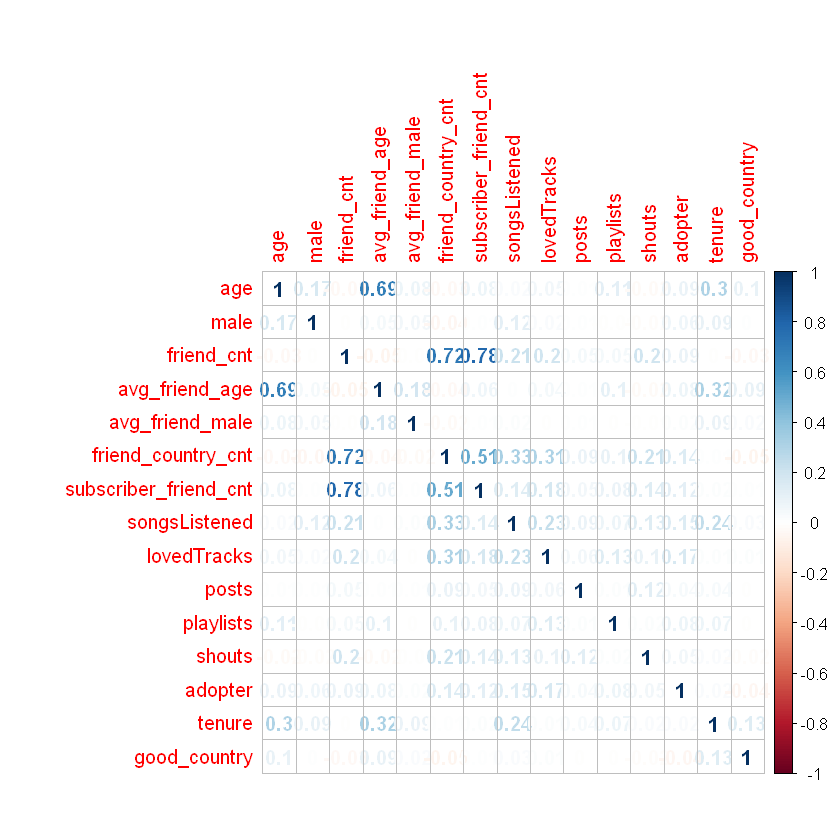

```r
M=cor(data,method = c("pearson", "kendall", "spearman"))
corrplot(M,method="number",addrect=2)
```

We define treatment as users who have one or more than 1 subscriber friends and study the variation of tratment across users from the two adopter classes

```r
data <- mutate(data,treatment=ifelse(data$subscriber_friend_cnt >=1,1,0))
data %>%
  group_by(adopter) %>% summarise(mean_treatment = mean(treatment),users=n())
```

| adopter | mean_treatment | users |
| --- | --- | --- |
| 0 | 0.2004715 | 40300 |
| 1 | 0.4944712 | 3527 |

There seems to be a difference in the treatment for the two class of adopters since the means are not similar so we run a t-test to find if there is any significance.

```r
with(data, t.test(treatment ~ adopter))
```

```
	Welch Two Sample t-test

data:  treatment by adopter
t = -33.978, df = 3931.7, p-value < 0.00000000000000022
alternative hypothesis: true difference in means is not equal to 0
95 percent confidence interval:
 -0.3109641 -0.2770354
sample estimates:
mean in group 0 mean in group 1
      0.2004715       0.4944712
```

So we can say that the treatment is a significant predictor and try understanding the significance across covariants

```r
data %>%
  group_by(treatment) %>%
  summarise_all(funs(mean(., na.rm = T)))
```

| treatment | age | male | friend_cnt | avg_friend_age | avg_friend_male | friend_country_cnt | subscriber_friend_cnt | songsListened | lovedTracks | posts | playlists | shouts | adopter | tenure | good_country |
| --- | --- | --- | --- | --- | --- | --- | --- | --- | --- | --- | --- | --- | --- | --- | --- |
| 0 | 23.74756 | 0.6288378 | 10.43133 | 23.76137 | 0.6131124 | 2.725062 | 0.000000 | 14602.22 | 65.21365 | 2.543377 | 0.5294671 | 16.42304 | 0.05243501 | 43.20268 | 0.3546936 |
| 1 | 25.37321 | 0.6362618 | 54.02097 | 25.39043 | 0.6358077 | 9.385626 | 2.300417 | 33735.64 | 225.36465 | 20.522956 | 0.7440700 | 101.81951 | 0.17754250 | 46.54871 | 0.3432760 |

We can see there is a significant difference in mean of the etimators for the treatment so we run a t-test on the means.

They is significance between them since the means are not the same so we calculate the t-test for each covariate by treatment status

```r
labels <- c('age','male','friend_cnt','avg_friend_age','avg_friend_male','friend_country_cnt','songsListened','lovedTracks','posts','playlists','shouts','tenure','good_country')

lapply(labels, function(v) {
  t.test(data[, v] ~ data$treatment)
 })
```

```
[[1]]

	Welch Two Sample t-test

data:  data[, v] by data$treatment
t = -20.841, df = 14645, p-value < 0.00000000000000022
alternative hypothesis: true difference in means is not equal to 0
95 percent confidence interval:
 -1.778544 -1.472749
sample estimates:
mean in group 0 mean in group 1
       23.74756        25.37321


[[2]]

	Welch Two Sample t-test

data:  data[, v] by data$treatment
t = -1.3459, df = 15986, p-value = 0.1784
alternative hypothesis: true difference in means is not equal to 0
95 percent confidence interval:
 -0.018236129  0.003388028
sample estimates:
mean in group 0 mean in group 1
      0.6288378       0.6362618


[[3]]

	Welch Two Sample t-test

data:  data[, v] by data$treatment
t = -33.707, df = 9903.1, p-value < 0.00000000000000022
alternative hypothesis: true difference in means is not equal to 0
95 percent confidence interval:
 -46.12459 -41.05469
sample estimates:
mean in group 0 mean in group 1
       10.43133        54.02097
```

[output cut: 125 more lines]

```
       43.20268        46.54871


[[13]]

	Welch Two Sample t-test

data:  data[, v] by data$treatment
t = 2.0956, df = 16030, p-value = 0.03613
alternative hypothesis: true difference in means is not equal to 0
95 percent confidence interval:
 0.0007383591 0.0220968020
sample estimates:
mean in group 0 mean in group 1
      0.3546936       0.3432760
```

# Propensity score estimation

We estimate the propensity score by running a logit model (probit also works), where the outcome variable is a binary variable indicating treatment status.

It helps understand covariates(Independent Variables) we should include for the matching to give a causal estimate.In the end, you need to include any covariate that is related to both the treatment assignment and potential outcomes

```r
model_pse <- glm(treatment ~  age+male+friend_cnt+avg_friend_age+avg_friend_male+friend_country_cnt+songsListened+lovedTracks+posts+playlists+shouts+tenure+good_country,
            family = binomial(), data = data)
summary(model_pse)
```

```
Call:
glm(formula = treatment ~ age + male + friend_cnt + avg_friend_age +
    avg_friend_male + friend_country_cnt + songsListened + lovedTracks +
    posts + playlists + shouts + tenure + good_country, family = binomial(),
    data = data)

Deviance Residuals:
    Min       1Q   Median       3Q      Max
-4.4206  -0.5671  -0.4220  -0.3001   2.5619

Coefficients:
                        Estimate    Std. Error z value             Pr(>|z|)
(Intercept)        -5.1439677039  0.0770258529 -66.782 < 0.0000000000000002 ***
age                 0.0196976670  0.0028079947   7.015      0.0000000000023 ***
male                0.0431142354  0.0299809578   1.438             0.150419
friend_cnt          0.0313218488  0.0010337026  30.301 < 0.0000000000000002 ***
avg_friend_age      0.0795507296  0.0034814999  22.850 < 0.0000000000000002 ***
avg_friend_male     0.2513881424  0.0502850056   4.999      0.0000005754883 ***
friend_country_cnt  0.1110348187  0.0047649448  23.302 < 0.0000000000000002 ***
songsListened       0.0000069064  0.0000005156  13.396 < 0.0000000000000002 ***
lovedTracks         0.0006670647  0.0000564517  11.817 < 0.0000000000000002 ***
posts               0.0005699077  0.0002682316   2.125             0.033613 *
playlists           0.0056389408  0.0118975589   0.474             0.635530
shouts             -0.0000490853  0.0000370677  -1.324             0.185434
tenure             -0.0025711127  0.0007768961  -3.309             0.000935 ***
good_country        0.0320120020  0.0292175239   1.096             0.273235
---
Signif. codes:  0 '***' 0.001 '**' 0.01 '*' 0.05 '.' 0.1 ' ' 1

(Dispersion parameter for binomial family taken to be 1)

    Null deviance: 46640  on 43826  degrees of freedom
Residual deviance: 34170  on 43813  degrees of freedom
AIC: 34198

Number of Fisher Scoring iterations: 7
```

```r
vif(model_pse)
```

**age**

2.04995382490269

**male**

1.07756297220205

**friend_cnt**

2.18188358061786

**avg_friend_age**

2.0789590056998

**avg_friend_male**

1.05079267249795

**friend_country_cnt**

2.0390343851684

**songsListened**

1.25559712338634

**lovedTracks**

1.07740035880471

**posts**

1.0218019496916

**playlists**

1.03329607041451

**shouts**

1.02446124417626

**tenure**

1.2158719531236

**good_country**

1.03122083579625

Using this model, we can now calculate the propensity score for each user. It is simply the user’s predicted probability of being Treated, given the estimates from the logit model. Below, I calculate this propensity score using predict() and create a dataframe that has the propensity score as well as the users actual treatment status.

```r
propensity_score <- data.frame(pr_score = predict(model_pse, type = "response"),
                     treatment=model_pse$model$treatment)
```

We now examine the region of common support, so post estimating the propensity score, we plot histograms of the estimated propensity scores based on treatment status to study the distribution

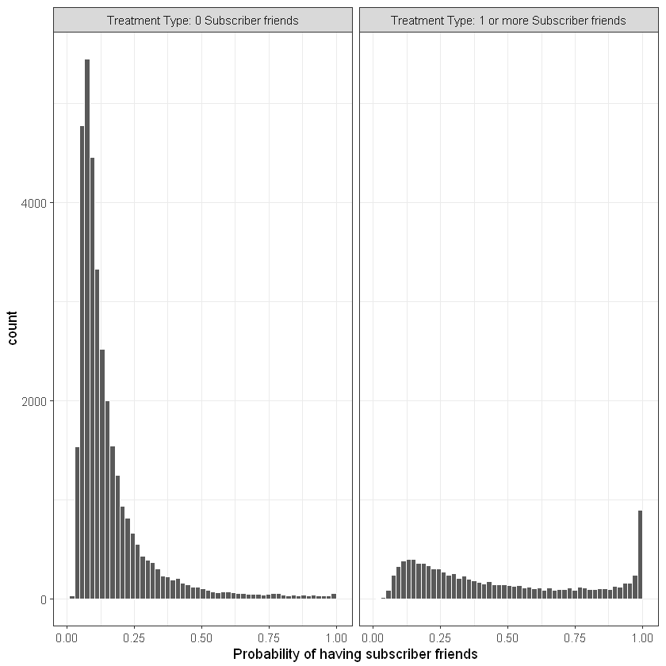

```r
labs <- paste("Treatment Type:", c("0 Subscriber friends", "1 or more Subscriber friends"))
propensity_score %>%
  mutate(treatment = ifelse(treatment == 0, labs[1], labs[2])) %>%
  ggplot(aes(x = pr_score)) +
  geom_histogram(color = "white",bins=55) +
  facet_wrap(~treatment) +
  xlab("Probability of having subscriber friends") +
  theme_bw()+xlim(0,1.01)
```

We check if there are NA Values before the matching since the MatchIt doesn't allow NA Values.

```r
sum(is.na(data))
```

0

Since the count of NA values is zero we proceed with the MatchIt function

```r
mod_match <- matchit(treatment ~ age+male+friend_cnt+avg_friend_age+avg_friend_male+friend_country_cnt+songsListened+lovedTracks+posts+playlists+shouts+tenure+good_country,
                     method = "nearest", data = data)
summary(mod_match)
```

```
Call:
matchit(formula = treatment ~ age + male + friend_cnt + avg_friend_age +
    avg_friend_male + friend_country_cnt + songsListened + lovedTracks +
    posts + playlists + shouts + tenure + good_country, data = data,
    method = "nearest")

Summary of balance for all data:
                   Means Treated Means Control SD Control  Mean Diff    eQQ Med
distance                  0.4635        0.1550     0.1436     0.3086     0.2506
age                      25.3732       23.7476     6.2245     1.6256     1.0000
male                      0.6363        0.6288     0.4831     0.0074     0.0000
friend_cnt               54.0210       10.4313    15.2769    43.5896    22.0000
avg_friend_age           25.3904       23.7614     5.0577     1.6291     1.5909
avg_friend_male           0.6358        0.6131     0.3343     0.0227     0.0738
friend_country_cnt        9.3856        2.7251     3.1024     6.6606     5.0000
songsListened         33735.6404    14602.2205 23214.2898 19133.4199 15471.0000
lovedTracks             225.3647       65.2137   181.4812   160.1510    65.0000
posts                    20.5230        2.5434    33.7947    17.9796     0.0000
playlists                 0.7441        0.5295     0.9673     0.2146     0.0000
shouts                  101.8195       16.4230    79.7381    85.3965    15.0000
tenure                   46.5487       43.2027    19.7212     3.3460     3.0000
good_country              0.3433        0.3547     0.4784    -0.0114     0.0000
                     eQQ Mean     eQQ Max
distance               0.3086      0.6840
age                    1.6296      5.0000
male                   0.0074      1.0000
friend_cnt            43.5838   4794.0000
avg_friend_age         1.6369     11.5000
avg_friend_male        0.0958      0.3636
friend_country_cnt     6.6598     95.0000
songsListened      19126.1623 653702.0000
lovedTracks          159.9562   6343.0000
posts                 17.8829   9535.0000
playlists              0.2092     26.0000
shouts                85.1764  59168.0000
tenure                 3.3473     10.0000
good_country           0.0114      1.0000


Summary of balance for matched data:
```

[output cut: 39 more lines]

```
friend_country_cnt    35.5279 60.0000   35.5203   0.0000
songsListened         66.6825 69.7499   66.6699  13.2836
lovedTracks           43.2906 41.5385   43.2216   2.5698
posts                 20.7676  0.0000   20.3394   0.0000
playlists             66.5567  0.0000   50.5109  15.3846
shouts                24.3724 33.3333   24.1770   0.0000
tenure                65.4771 66.6667   61.1782  60.0000
good_country         -30.1771  0.0000  -30.3571   0.0000

Sample sizes:
          Control Treated
All         34004    9823
Matched      9823    9823
Unmatched   24181       0
Discarded       0       0
```

Since there are 9823 records that have been treated[Subscriber Friend count is >= 1], the Matchit matches it with 9823 records from the Control that have the nearest Propensity score estimate.

So we now have 9823 treated and 9823 control records that have been matched based on Propensity score.

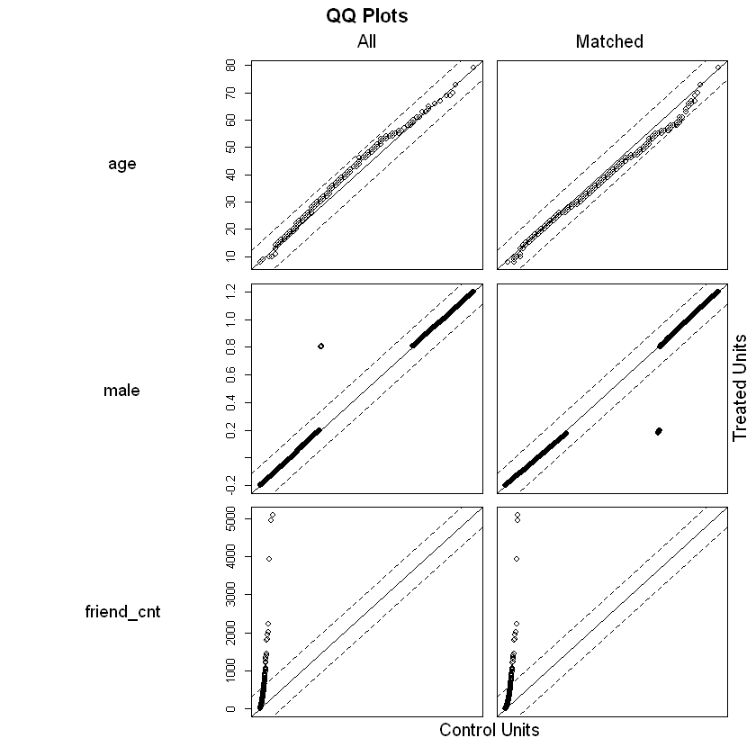

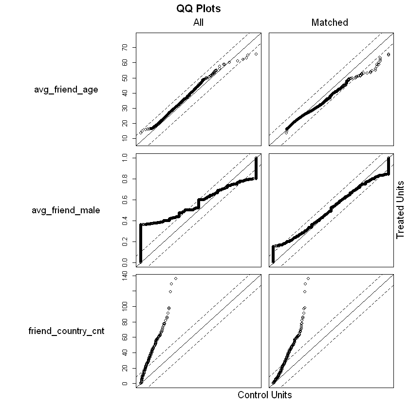

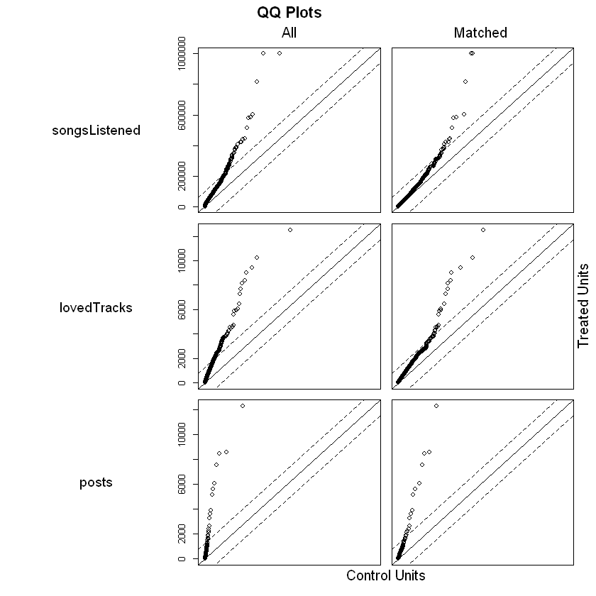

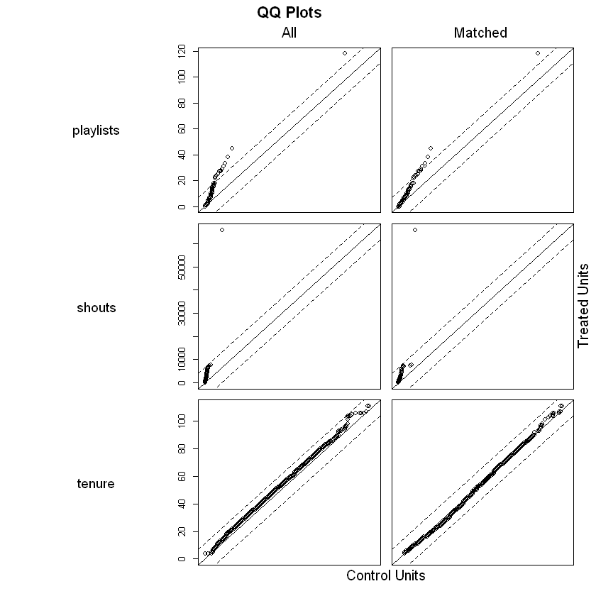

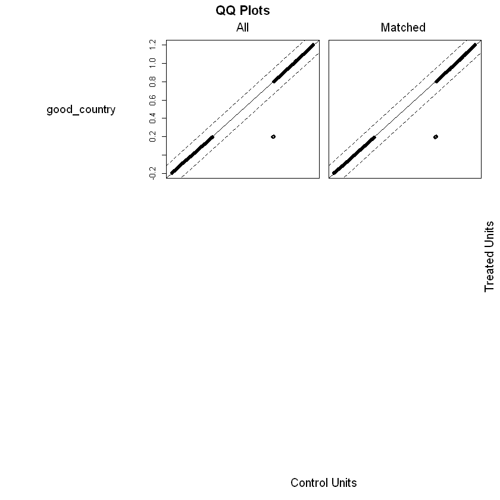

```r
plot(mod_match)
```

We now create a dataframe with only the 9823 treatment records and 9823 matched Control records using the match.data function.

```r
dta_m <- match.data(mod_match)
print("Dimensions of the matched data frame")
dim(dta_m)
print("Table of Treatment distriution in the matched data frame")
table(dta_m$treatment)
```

```
[1] "Dimensions of the matched data frame"
```

1. 19646

2. 18

```
[1] "Table of Treatment distriution in the matched data frame"
```

```
   0    1
9823 9823
```

Out of curiousity we want to study the distribution of Propensity score estimated distance across Control and Treatment. So we plot a boxplot for it.

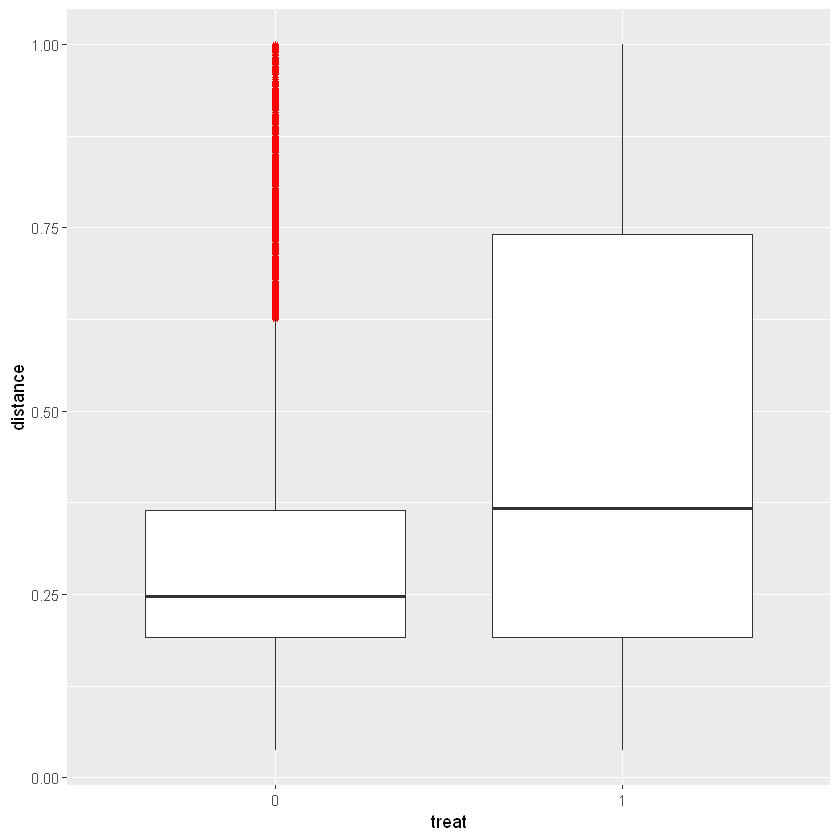

```r
dta_m$treat <- as.factor(dta_m$treatment)
abc2 <- ggplot(dta_m, aes(y=distance,x=treat)) + geom_boxplot(outlier.colour="red", outlier.shape=8,outlier.size=1)
abc2 <- abc2 +theme(legend.position="none")
abc2
dta_m$treat <- NULL
```

We can observe that there are covariates whose values are matched between treatment and control, so we do a visual inspection of it.

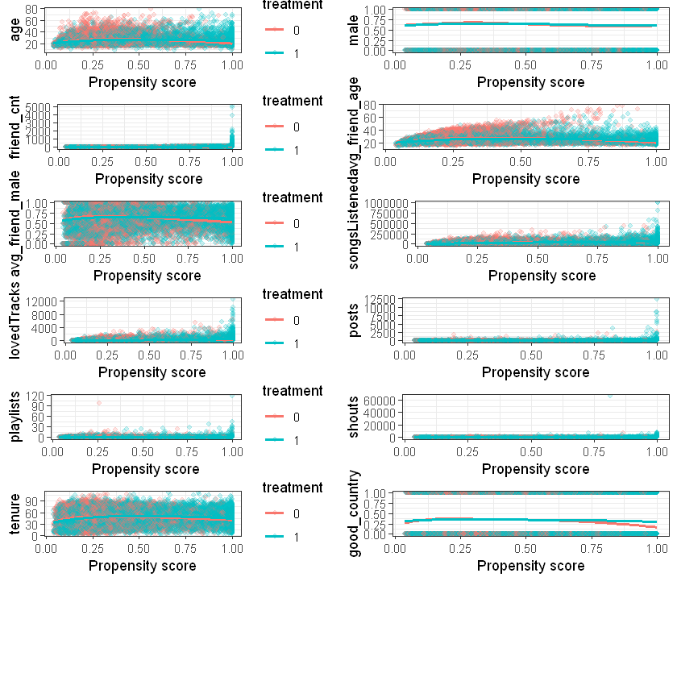

```r
fn_bal <- function(dta, variable) {
  dta$variable <- dta[, variable]
  dta$treatment <- as.factor(dta$treatment)
  support <- c(min(dta$variable), max(dta$variable))
  ggplot(dta, aes(x = distance, y = variable, color = treatment)) +
    geom_point(alpha = 0.2, size = 1.3) +
    geom_smooth(method = "loess", se = F) +
    xlab("Propensity score") +
    ylab(variable) +
    theme_bw() +
    ylim(support)
}

grid.arrange(
  fn_bal(dta_m, "age"),
  fn_bal(dta_m, "male") + theme(legend.position = "none"),
  fn_bal(dta_m, "friend_cnt"),
  fn_bal(dta_m, "avg_friend_age") + theme(legend.position = "none"),
  fn_bal(dta_m, "avg_friend_male"),
  fn_bal(dta_m, "songsListened") + theme(legend.position = "none"),
  fn_bal(dta_m, "lovedTracks"),
  fn_bal(dta_m, "posts") + theme(legend.position = "none"),
  fn_bal(dta_m, "playlists"),
  fn_bal(dta_m, "shouts") + theme(legend.position = "none"),
  fn_bal(dta_m, "tenure"),
  fn_bal(dta_m, "good_country") + theme(legend.position = "none"),
  nrow = 7)
```

We compare the means across the treatments post propensity score matching

```r
group_by(dta_m,treatment) %>%
  summarise_all(funs(mean(., na.rm = T)))
```

| treatment | age | male | friend_cnt | avg_friend_age | avg_friend_male | friend_country_cnt | subscriber_friend_cnt | songsListened | lovedTracks | posts | playlists | shouts | adopter | tenure | good_country | distance | weights |
| --- | --- | --- | --- | --- | --- | --- | --- | --- | --- | --- | --- | --- | --- | --- | --- | --- | --- |
| 0 | 26.33238 | 0.6576402 | 21.46656 | 26.55723 | 0.6551451 | 5.091418 | 0.000000 | 27360.86 | 134.5440 | 6.277308 | 0.6722997 | 37.23618 | 0.08683702 | 47.70386 | 0.3581391 | 0.3039891 | 1 |
| 1 | 25.37321 | 0.6362618 | 54.02097 | 25.39043 | 0.6358077 | 9.385626 | 2.300417 | 33735.64 | 225.3647 | 20.522956 | 0.7440700 | 101.81951 | 0.17754250 | 46.54871 | 0.3432760 | 0.4635421 | 1 |

The means are in range for selected predictors and we now try finding if the difference of means is significant through a t-test for the covariants

```r
labels <- c('age','male','friend_cnt','avg_friend_age','avg_friend_male','friend_country_cnt','songsListened','lovedTracks','posts','playlists','shouts','tenure','good_country')

lapply(labels, function(v) {
  t.test(dta_m[, v] ~ dta_m$treatment)
 })
```

```
[[1]]

	Welch Two Sample t-test

data:  dta_m[, v] by dta_m$treatment
t = 9.0201, df = 19340, p-value < 0.00000000000000022
alternative hypothesis: true difference in means is not equal to 0
95 percent confidence interval:
 0.750746 1.167609
sample estimates:
mean in group 0 mean in group 1
       26.33238        25.37321


[[2]]

	Welch Two Sample t-test

data:  dta_m[, v] by dta_m$treatment
t = 3.1356, df = 19640, p-value = 0.001718
alternative hypothesis: true difference in means is not equal to 0
95 percent confidence interval:
 0.008014461 0.034742334
sample estimates:
mean in group 0 mean in group 1
      0.6576402       0.6362618


[[3]]

	Welch Two Sample t-test

data:  dta_m[, v] by dta_m$treatment
t = -24.809, df = 10486, p-value < 0.00000000000000022
alternative hypothesis: true difference in means is not equal to 0
95 percent confidence interval:
 -35.12657 -29.98225
sample estimates:
mean in group 0 mean in group 1
       21.46656        54.02097
```

[output cut: 125 more lines]

```
       47.70386        46.54871


[[13]]

	Welch Two Sample t-test

data:  dta_m[, v] by dta_m$treatment
t = 2.183, df = 19642, p-value = 0.02905
alternative hypothesis: true difference in means is not equal to 0
95 percent confidence interval:
 0.001517727 0.028208426
sample estimates:
mean in group 0 mean in group 1
      0.3581391       0.3432760
```

We now Estimate the treatment effects since we have the matched sample that we are happy with. We can use a t-test:

```r
with(dta_m, t.test(adopter~ treatment))
```

```
	Welch Two Sample t-test

data:  adopter by treatment
t = -18.938, df = 18060, p-value < 0.00000000000000022
alternative hypothesis: true difference in means is not equal to 0
95 percent confidence interval:
 -0.10009352 -0.08131745
sample estimates:
mean in group 0 mean in group 1
     0.08683702      0.17754250
```

## Machine Learning

Now, we will use a logistic regression approach to test which variables (including subscriber friends) are significant for explaining the likelihood of becoming an adopter. We use our judgment and visualization results to decide which variables to include in the regression. We also estimate the odds ratios for the key variables.

## Model1:

We build a glm model with only the treatment variable to check if it is a significant predictor of the adopter variable.

```r
glm_treat1 <- glm(adopter ~ treatment, data = dta_m,family='binomial')
summary(glm_treat1)
```

```
Call:
glm(formula = adopter ~ treatment, family = "binomial", data = dta_m)

Deviance Residuals:
    Min       1Q   Median       3Q      Max
-0.6252  -0.6252  -0.4262  -0.4262   2.2108

Coefficients:
            Estimate Std. Error z value            Pr(>|z|)
(Intercept) -2.35288    0.03583  -65.67 <0.0000000000000002 ***
treatment    0.81979    0.04451   18.42 <0.0000000000000002 ***
---
Signif. codes:  0 '***' 0.001 '**' 0.01 '*' 0.05 '.' 0.1 ' ' 1

(Dispersion parameter for binomial family taken to be 1)

    Null deviance: 15345  on 19645  degrees of freedom
Residual deviance: 14986  on 19644  degrees of freedom
AIC: 14990

Number of Fisher Scoring iterations: 5
```

```r
exp(coef(glm_treat1))
```

**(Intercept)**

0.0950947603121052

**treatment**

2.2700335941088

The treatment [Having subscriber friends] is a significant predictor in judging if the user will be a free or a fee user. The odds ratio of the treatment is 2.27 which is greater than 1 and hence supports the case, also the probability is almost zero which makes it a good predictor

## Model 2

We now build a glm model with the treatment variable and other covariates to predict the adopter status.

```r
glm_treat2 <- glm(adopter ~ treatment+age+male+friend_cnt+avg_friend_age+avg_friend_male+friend_country_cnt+songsListened+lovedTracks+posts+playlists+shouts+tenure+good_country+treatment, data = dta_m,family='binomial')
summary(glm_treat2)
```

```
Call:
glm(formula = adopter ~ treatment + age + male + friend_cnt +
    avg_friend_age + avg_friend_male + friend_country_cnt + songsListened +
    lovedTracks + posts + playlists + shouts + tenure + good_country +
    treatment, family = "binomial", data = dta_m)

Deviance Residuals:
    Min       1Q   Median       3Q      Max
-3.2240  -0.5668  -0.4562  -0.3697   2.5257

Coefficients:
                        Estimate    Std. Error z value             Pr(>|z|)
(Intercept)        -3.3709684810  0.1261268190 -26.727 < 0.0000000000000002 ***
treatment           0.7292753804  0.0468153008  15.578 < 0.0000000000000002 ***
age                 0.0141945749  0.0040691111   3.488             0.000486 ***
male                0.3039659743  0.0489909251   6.205 0.000000000548584009 ***
friend_cnt         -0.0002001575  0.0002792679  -0.717             0.473545
avg_friend_age      0.0130425316  0.0053490465   2.438             0.014757 *
avg_friend_male     0.0600688475  0.0925246717   0.649             0.516196
friend_country_cnt  0.0072774704  0.0036486080   1.995             0.046088 *
songsListened       0.0000042553  0.0000005301   8.027 0.000000000000000997 ***
lovedTracks         0.0005210828  0.0000469224  11.105 < 0.0000000000000002 ***
posts               0.0001186059  0.0000889116   1.334             0.182212
playlists           0.0446485958  0.0119444028   3.738             0.000185 ***
shouts              0.0001119478  0.0000745439   1.502             0.133156
tenure             -0.0024335424  0.0012170876  -1.999             0.045556 *
good_country       -0.3694917638  0.0480180878  -7.695 0.000000000000014167 ***
---
Signif. codes:  0 '***' 0.001 '**' 0.01 '*' 0.05 '.' 0.1 ' ' 1

(Dispersion parameter for binomial family taken to be 1)

    Null deviance: 15345  on 19645  degrees of freedom
Residual deviance: 14493  on 19631  degrees of freedom
AIC: 14523

Number of Fisher Scoring iterations: 5
```

Predictor variables such as friend count, average friend being a male, posts and shouts don't have much significance in deciding if the user would be a free or a fee customer. Variables such as age, gender, having subscriber friends, songs listened, loved tracks, country from and playlists have significant impact on the adopter variable.

## Model 3 - Enhancement of Model 2 with significant predictors

We build the third glm model with only the significant predictors from the glm_model_2

```r
glm_treat3 <- glm(adopter ~ treatment+age+male+avg_friend_age+friend_country_cnt+songsListened+lovedTracks+playlists+tenure+good_country, data = dta_m)
summary(glm_treat3)
```

```
Call:
glm(formula = adopter ~ treatment + age + male + avg_friend_age +
    friend_country_cnt + songsListened + lovedTracks + playlists +
    tenure + good_country, data = dta_m)

Deviance Residuals:
     Min        1Q    Median        3Q       Max
-1.28859  -0.15589  -0.10624  -0.05655   0.99818

Coefficients:
                         Estimate     Std. Error t value             Pr(>|t|)
(Intercept)        -0.03377255980  0.01265349611  -2.669             0.007613
treatment           0.07693526599  0.00490039844  15.700 < 0.0000000000000002
age                 0.00171597141  0.00045852615   3.742             0.000183
male                0.03029474232  0.00511504251   5.923  0.00000000322022844
avg_friend_age      0.00165086368  0.00056940879   2.899             0.003745
friend_country_cnt  0.00108730614  0.00032514409   3.344             0.000827
songsListened       0.00000063991  0.00000006592   9.708 < 0.0000000000000002
lovedTracks         0.00008598994  0.00000596592  14.414 < 0.0000000000000002
playlists           0.00719924354  0.00140642590   5.119  0.00000031035110903
tenure             -0.00028898123  0.00013195338  -2.190             0.028534
good_country       -0.03911872213  0.00501421899  -7.802  0.00000000000000642

(Intercept)        **
treatment          ***
age                ***
male               ***
avg_friend_age     **
friend_country_cnt ***
songsListened      ***
lovedTracks        ***
playlists          ***
tenure             *
good_country       ***
---
Signif. codes:  0 '***' 0.001 '**' 0.01 '*' 0.05 '.' 0.1 ' ' 1

(Dispersion parameter for gaussian family taken to be 0.1091944)

    Null deviance: 2253.7  on 19645  degrees of freedom
Residual deviance: 2144.0  on 19635  degrees of freedom
AIC: 12257

Number of Fisher Scoring iterations: 2
```

```r
exp(coef(glm_treat3))
```

**(Intercept)**

0.966791366857988

**treatment**

1.07997216320288

**age**

1.00171744452899

**male**

1.03075829727984

**avg_friend_age**

1.00165222711008

**friend_country_cnt**

1.00108789747467

**songsListened**

1.00000063991448

**lovedTracks**

1.00008599363375

**playlists**

1.00722522039738

**tenure**

0.999711060519472

**good_country**

0.961636534833834

## Model 4 - [Model 3 with original data]

We build a glm model with the same significant predictors from glm_model_3 but with the original dataset which has not been matched by propensity score, to try finding if the odds ratio are similar.

```r
glm_treat4 <- glm(adopter ~ treatment+age+male+avg_friend_age+friend_country_cnt+songsListened+lovedTracks+playlists+tenure+good_country, data = data)
summary(glm_treat4)
```

```
Call:
glm(formula = adopter ~ treatment + age + male + avg_friend_age +
    friend_country_cnt + songsListened + lovedTracks + playlists +
    tenure + good_country, data = data)

Deviance Residuals:
     Min        1Q    Median        3Q       Max
-1.39105  -0.09437  -0.05231  -0.02488   1.00860

Coefficients:
                         Estimate     Std. Error t value             Pr(>|t|)
(Intercept)        -0.04683542149  0.00642124147  -7.294    0.000000000000306
treatment           0.08132195744  0.00346437697  23.474 < 0.0000000000000002
age                 0.00196724618  0.00027577639   7.133    0.000000000000994
male                0.02433625105  0.00267685896   9.091 < 0.0000000000000002
avg_friend_age      0.00166388874  0.00034601544   4.809    0.000001524090572
friend_country_cnt  0.00126832808  0.00024434666   5.191    0.000000210447684
songsListened       0.00000071282  0.00000004673  15.252 < 0.0000000000000002
lovedTracks         0.00009302361  0.00000460858  20.185 < 0.0000000000000002
playlists           0.00834912229  0.00101197896   8.250 < 0.0000000000000002
tenure             -0.00040899303  0.00007013351  -5.832    0.000000005527125
good_country       -0.02528691859  0.00265970867  -9.507 < 0.0000000000000002

(Intercept)        ***
treatment          ***
age                ***
male               ***
avg_friend_age     ***
friend_country_cnt ***
songsListened      ***
lovedTracks        ***
playlists          ***
tenure             ***
good_country       ***
---
Signif. codes:  0 '***' 0.001 '**' 0.01 '*' 0.05 '.' 0.1 ' ' 1

(Dispersion parameter for gaussian family taken to be 0.06890903)

    Null deviance: 3243.2  on 43826  degrees of freedom
Residual deviance: 3019.3  on 43816  degrees of freedom
AIC: 7152.8

Number of Fisher Scoring iterations: 2
```

```r
exp(coef(glm_treat4))
```

**(Intercept)**

0.954244432793385

**treatment**

1.08472007405549

**age**

1.00196918248207

**male**

1.02463479449688

**avg_friend_age**

1.00166527377069

**friend_country_cnt**

1.00126913274682

**songsListened**

1.00000071281978

**lovedTracks**

1.0000930279376

**playlists**

1.00838407341705

**tenure**

0.999591090595412

**good_country**

0.975030117623811

Our conclusion from the result would be that, the odds ratio of the user converting to a paid subscriber of the music app increases if the user has friends who are subscribers as well. Also it was found that people who are older tend to have sunscriptions because of the affordability factor and males have a higher probability of converting to paid users.

## Business Takeaways

Key take aways from our analysis and the suggestions we would give High Note for a “free-to-fee” strategy would be the following. We find that demographics, peer influence, user engagement all have good effect on the adopter variable and hence formulate the below findings and suggestions to the company.

> Having subscriber friends has a positive effect in increasing the odds of becoming a fee customer. So we want to offer group packages and referral schemes to get more users excited about the paid subscription.

> As the tenure increases the likelihood of converting to a paid customer reduces, so we want to target the user with ads more during the initial phase of usage.

> Songs listened, Loved tracks and playlists all have positive odds ratio and hence to capitalise on it we want to increase the number of songs offered, maybe expand with regional songs to improve user engagement.

> If the user is from a good country the odds ratio of him converting is lesser because there are more competitive players in the market and we want to personalise the app more in such countries.

> Friend Country count has a positive effect on the odds ratio so we can suggest people from other countries as friends in the recommendation to enhace chances.